# Multiple Linear Regression Modeling

#### Project Purpose

This project uses the data that was previously cleaned in the Jupyter Notebook "Data Cleaning". The majority of the data set is used to determine how tenure might be predicted. I plan to pare down the list of variables not by what might intuitively belong together, but by looking at numerical calculations that suggest which variables are significant to answering the research question. Armed with these variables, I hope to obtain a strong predictive model to assist the telecommunications company with decisions on how to increase tenure in its customer base.

#### Steps to Prepare the Data

The following steps will be taken to prepare the data for analysis:

1. Import data to pandas dataframe
2. Determine variable types and those which may require further investigation
3. Convert binary variables to yes = 1 and no = 0
4. Investigate potential categorical variables using bar charts, then convert categorical values to dummy variables
5. Drop columns that will not be used in regression analysis

##### Step 1

```python
# Import necessary libraries
import pandas as pd
import numpy as np
%matplotlib inline
import matplotlib as mpl
import matplotlib.pyplot as plt
from matplotlib.patches import Rectangle
import seaborn as sns
from sklearn import linear_model
from sklearn.linear_model import LinearRegression
from statsmodels.stats.outliers_influence import variance_inflation_factor
from sklearn.model_selection import cross_val_predict, train_test_split
from sklearn.linear_model import Lasso, LassoCV, Ridge, RidgeCV
import statsmodels.api as sm
import statsmodels.formula.api as smf
from yellowbrick.regressor import AlphaSelection, PredictionError, ResidualsPlot
import warnings
warnings.filterwarnings('ignore') # Ignore warning messages for readability
```

```python
# Read in dataset and view head
df = pd.read_csv('churn_clean_data.csv', dtype={'Zip Code': 'str'})
pd.options.display.max_columns = None
df.head()
```

|  | CustomerID | Count | Country | State | City | Zip Code | Lat Long | Latitude | Longitude | Gender | Senior Citizen | Partner | Dependents | Tenure Months | Phone Service | Multiple Lines | Internet Service | Online Security | Online Backup | Device Protection | Tech Support | Streaming TV | Streaming Movies | Contract | Paperless Billing | Payment Method | Monthly Charges | Total Charges | Churn Label | … |
| --- | --- | --- | --- | --- | --- | --- | --- | --- | --- | --- | --- | --- | --- | --- | --- | --- | --- | --- | --- | --- | --- | --- | --- | --- | --- | --- | --- | --- | --- | --- |
| 0 | 3668-QPYBK | 1 | United States | California | Los Angeles | 90003 | 33.964131, -118.272783 | 33.964131 | -118.272783 | Male | No | No | No | 2.0 | Yes | No | DSL | Yes | Yes | No | No | No | No | Month-to-month | Yes | Mailed check | 53.85 | 108.15 | Yes | … |
| 1 | 9237-HQITU | 1 | United States | California | Los Angeles | 90005 | 34.059281, -118.30742 | 34.059281 | -118.307420 | Female | No | No | Yes | 2.0 | Yes | No | Fiber optic | No | No | No | No | No | No | Month-to-month | Yes | Electronic check | 70.70 | 151.65 | Yes | … |
| 2 | 9305-CDSKC | 1 | United States | California | Los Angeles | 90006 | 34.048013, -118.293953 | 34.048013 | -118.293953 | Female | No | No | Yes | 8.0 | Yes | Yes | Fiber optic | No | No | Yes | No | Yes | Yes | Month-to-month | Yes | Electronic check | 99.65 | 820.50 | Yes | … |
| 3 | 7892-POOKP | 1 | United States | California | Los Angeles | 90010 | 34.062125, -118.315709 | 34.062125 | -118.315709 | Female | No | Yes | Yes | 28.0 | Yes | Yes | Fiber optic | No | No | Yes | Yes | Yes | Yes | Month-to-month | Yes | Electronic check | 104.80 | 3046.05 | Yes | … |
| 4 | 0280-XJGEX | 1 | United States | California | Los Angeles | 90015 | 34.039224, -118.266293 | 34.039224 | -118.266293 | Male | No | No | Yes | 49.0 | Yes | Yes | Fiber optic | No | Yes | Yes | No | Yes | Yes | Month-to-month | Yes | Bank transfer (automatic) | 103.70 | 5036.30 | Yes | … |

##### Step 2

```python
# View list of columns, data types, and missing values
df.info()
```

```
<class 'pandas.core.frame.DataFrame'>
RangeIndex: 7043 entries, 0 to 7042
Data columns (total 33 columns):
 #   Column             Non-Null Count  Dtype
---  ------             --------------  -----
 0   CustomerID         7043 non-null   object
 1   Count              7043 non-null   int64
 2   Country            7043 non-null   object
 3   State              7043 non-null   object
 4   City               7043 non-null   object
 5   Zip Code           7043 non-null   object
 6   Lat Long           7043 non-null   object
 7   Latitude           7043 non-null   float64
 8   Longitude          7043 non-null   float64
 9   Gender             7043 non-null   object
```

[output cut: 25 more lines]

```python
df.columns
```

```
Index(['CustomerID', 'Count', 'Country', 'State', 'City', 'Zip Code',
       'Lat Long', 'Latitude', 'Longitude', 'Gender', 'Senior Citizen',
       'Partner', 'Dependents', 'Tenure Months', 'Phone Service',
       'Multiple Lines', 'Internet Service', 'Online Security',
       'Online Backup', 'Device Protection', 'Tech Support', 'Streaming TV',
       'Streaming Movies', 'Contract', 'Paperless Billing', 'Payment Method',
       'Monthly Charges', 'Total Charges', 'Churn Label', 'Churn Value',
       'Churn Score', 'CLTV', 'Churn Reason'],
      dtype='object')
```

##### Results of Step 2

- There are no missing values and the dataset is clean and ready to prepare for analysis.

##### Breakdown of Variables

###### Identification variables:

- CustomerID

###### String variables:

- State, City, Zip Code, Lat Long

###### Numeric variables:

- Count, Latitude, Longitude, Tenure Months, Monthly Charges, Total Charges, Churn Value, Churn Score, CLTV

###### Possible Categorical variables (may be string, will investigate further):

- Country, Gender, Multiple Lines, Internet Service, Online Security, Online Backup, Device Protection, Tech Support, Streaming TV, Streaming Movies, Contract, Payment Method, Churn Reason

##### Step 3

```python
# Convert binary variables into yes = 1, no = 0 (ref 1)
cols = ['Senior Citizen', 'Partner', 'Dependents', 'Phone Service', 'Paperless Billing', 'Churn Label']
df[cols] = df[cols].replace(to_replace = ['No', 'Yes'], value = [0, 1])
```

##### Step 4

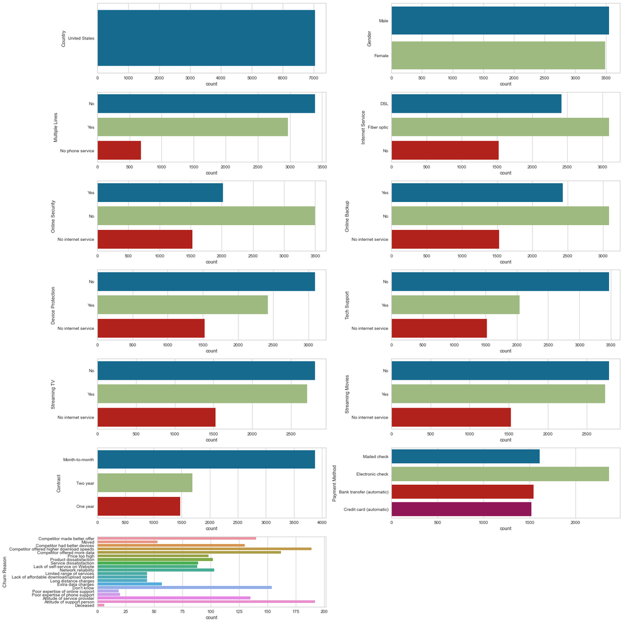

```python
# View bar charts for potential categorical variables to determine number of categories
figure, axes = plt.subplots(nrows=7, ncols=2, figsize=(20,20))
plt.subplot(7, 2, 1)
sns.countplot(data = df, y = 'Country')
plt.subplot(7, 2, 2)
sns.countplot(data = df, y = 'Gender')
plt.subplot(7, 2, 3)
sns.countplot(data = df, y = 'Multiple Lines')
plt.subplot(7, 2, 4)
sns.countplot(data = df, y = 'Internet Service')
plt.subplot(7, 2, 5)
sns.countplot(data = df, y = 'Online Security')
plt.subplot(7, 2, 6)
sns.countplot(data = df, y = 'Online Backup')
plt.subplot(7, 2, 7)
sns.countplot(data = df, y = 'Device Protection')
plt.subplot(7, 2, 8)
sns.countplot(data = df, y = 'Tech Support')
plt.subplot(7, 2, 9)
sns.countplot(data = df, y = 'Streaming TV')
plt.subplot(7, 2, 10)
sns.countplot(data = df, y = 'Streaming Movies')
plt.subplot(7, 2, 11)
sns.countplot(data = df, y = 'Contract')
plt.subplot(7, 2, 12)
sns.countplot(data = df, y = 'Payment Method')
plt.subplot(7, 2, 13)
sns.countplot(data = df, y = 'Churn Reason')
plt.subplot(7, 2, 14).set_visible(False)
figure.tight_layout()
plt.show();
```

- Country appears to currently only have one value, so will be treated as a string. The remaining variables will be converted into dummy variables.

```python
# Create separate variables for each categorical value, with a 1 if the value is present in that row and 0 if not present
df = pd.get_dummies(data=df, columns=['Gender', 'Multiple Lines', 'Internet Service', 'Online Security', 'Online Backup',
                                      'Device Protection', 'Tech Support', 'Streaming TV', 'Streaming Movies',
                                      'Contract', 'Payment Method', 'Churn Reason'])
```

##### Step 5

```python
# Drop columns not needed for analysis
drops = ['CustomerID', 'Country', 'State', 'City', 'Zip Code', 'Lat Long']
df = df.drop(drops, axis = 1)
```

#### VISUALIZATIONS

##### Univariate Visualizations

```python
df.info()
```

```
<class 'pandas.core.frame.DataFrame'>
RangeIndex: 7043 entries, 0 to 7042
Data columns (total 68 columns):
 #   Column                                                  Non-Null Count  Dtype
---  ------                                                  --------------  -----
 0   Count                                                   7043 non-null   int64
 1   Latitude                                                7043 non-null   float64
 2   Longitude                                               7043 non-null   float64
 3   Senior Citizen                                          7043 non-null   int64
 4   Partner                                                 7043 non-null   int64
 5   Dependents                                              7043 non-null   int64
 6   Tenure Months                                           7043 non-null   float64
 7   Phone Service                                           7043 non-null   int64
 8   Paperless Billing                                       7043 non-null   int64
 9   Monthly Charges                                         7043 non-null   float64
```

[output cut: 60 more lines]

```python
df.columns
```

```
Index(['Count', 'Latitude', 'Longitude', 'Senior Citizen', 'Partner',
       'Dependents', 'Tenure Months', 'Phone Service', 'Paperless Billing',
       'Monthly Charges', 'Total Charges', 'Churn Label', 'Churn Value',
       'Churn Score', 'CLTV', 'Gender_Female', 'Gender_Male',
       'Multiple Lines_No', 'Multiple Lines_No phone service',
       'Multiple Lines_Yes', 'Internet Service_DSL',
       'Internet Service_Fiber optic', 'Internet Service_No',
       'Online Security_No', 'Online Security_No internet service',
       'Online Security_Yes', 'Online Backup_No',
       'Online Backup_No internet service', 'Online Backup_Yes',
       'Device Protection_No', 'Device Protection_No internet service',
       'Device Protection_Yes', 'Tech Support_No',
       'Tech Support_No internet service', 'Tech Support_Yes',
       'Streaming TV_No', 'Streaming TV_No internet service',
       'Streaming TV_Yes', 'Streaming Movies_No',
       'Streaming Movies_No internet service', 'Streaming Movies_Yes',
       'Contract_Month-to-month', 'Contract_One year', 'Contract_Two year',
       'Payment Method_Bank transfer (automatic)',
       'Payment Method_Credit card (automatic)',
       'Payment Method_Electronic check', 'Payment Method_Mailed check',
       'Churn Reason_Attitude of service provider',
       'Churn Reason_Attitude of support person',
       'Churn Reason_Competitor had better devices',
       'Churn Reason_Competitor made better offer',
       'Churn Reason_Competitor offered higher download speeds',
       'Churn Reason_Competitor offered more data', 'Churn Reason_Deceased',
       'Churn Reason_Don't know', 'Churn Reason_Extra data charges',
       'Churn Reason_Lack of affordable download/upload speed',
       'Churn Reason_Lack of self-service on Website',
       'Churn Reason_Limited range of services',
       'Churn Reason_Long distance charges', 'Churn Reason_Moved',
       'Churn Reason_Network reliability',
       'Churn Reason_Poor expertise of online support',
       'Churn Reason_Poor expertise of phone support',
       'Churn Reason_Price too high', 'Churn Reason_Product dissatisfaction',
       'Churn Reason_Service dissatisfaction'],
      dtype='object')
```

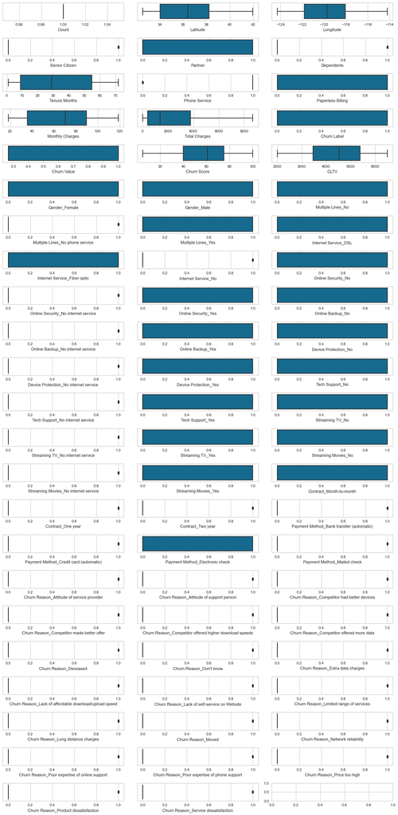

```python
# Display boxplots of numeric columns (ref 2)
cols = df.columns
f, axes = plt.subplots(round(len(cols)/3), 3, figsize=(15,30))
y = 0;
for col in cols:
    i, j = divmod(y, 3)
    sns.boxplot(x=df[col], ax=axes[i, j])
    y = y + 1

plt.tight_layout()
plt.show();
```

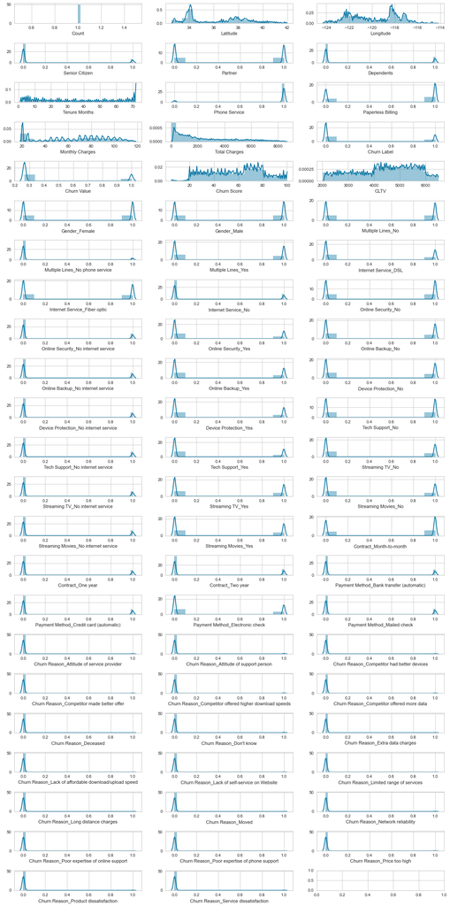

```python
# Display histograms of numeric columns (ref 2)
f, axes = plt.subplots(round(len(cols)/3), 3, figsize=(15,30))
y = 0;
for col in cols:
    i, j = divmod(y, 3)
    sns.distplot(df[col], ax=axes[i, j], kde_kws={'bw':0.01})
    y = y + 1

plt.tight_layout()
plt.show();
```

##### Bivariate Visualizations

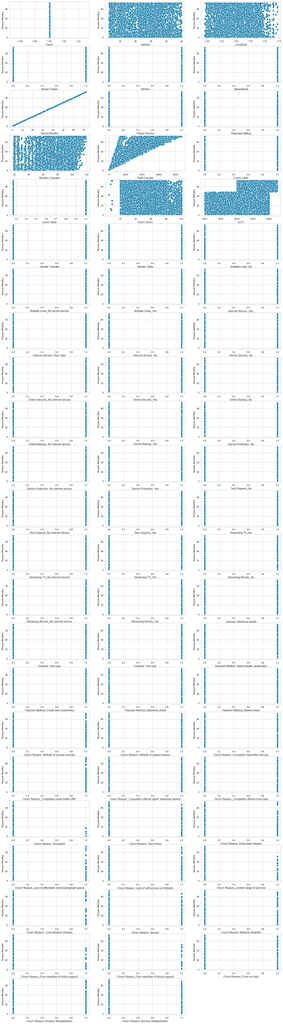

```python
# Plot scatter plots for each predictive variable on the x axis and Tenure on y axis (Ref 3)
count=1
plt.subplots(figsize=(20, 80))
for i in df.columns:
    plt.subplot(24,3,count)
    sns.scatterplot(df[i], df["Tenure Months"])
    count+=1

plt.show()
```

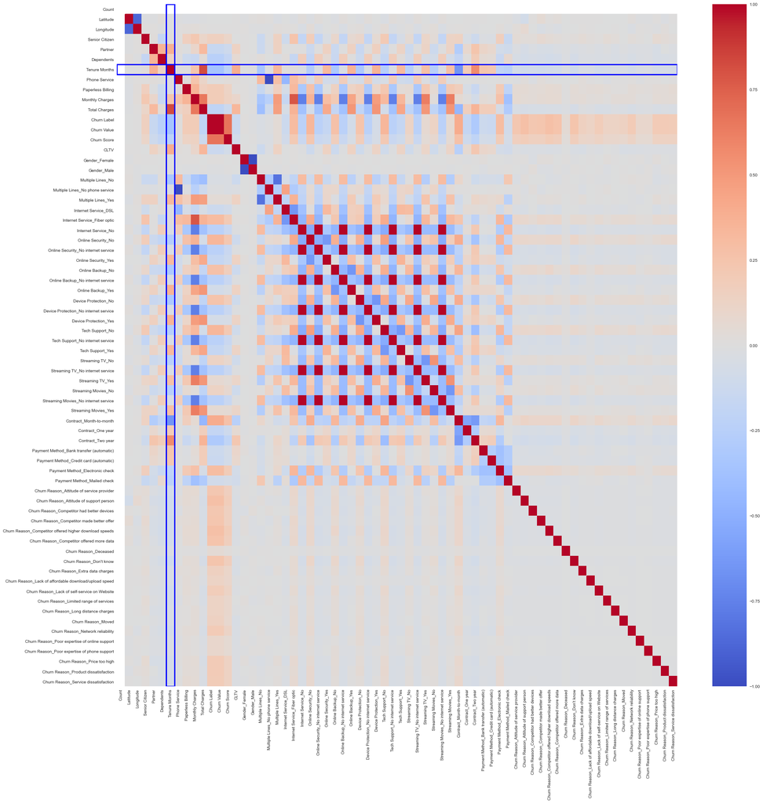

```python
# Display heatmap to view correlation between variables highlighting the Tenure variable (ref 4)
t = df.columns.get_loc('Tenure Months')
l = len(df.columns)
fig, ax = plt.subplots(figsize=(30,30))
sns.heatmap(df.corr(), cmap='coolwarm')
ax.add_patch(Rectangle((t, 0), 1, l, fill=False, edgecolor='blue', lw=3))
ax.add_patch(Rectangle((0, t), l, 1, fill=False, edgecolor='blue', lw=3))
plt.show()
```

#### Prepared Data

```python
# Save cleaned dataframe to CSV
df.to_csv('churn_clean_data_final.csv', index = False, encoding = 'utf-8')
```

#### Initial Model

```python
# Set up input matrix and response variable
observations = len(df)
variables = df.columns[:-1]
Xinit = df.iloc[:,:-1]
y = df['Tenure Months'].values
```

```python
# Veiw number of independent variables
print ("There are", Xinit.shape[1], "independent variables in the initial model.")
```

```
There are 67 independent variables in the initial model.
```

```python
# Add y-intercept, create model, and view summary
Xc_init = sm.add_constant(Xinit)
linear_regression = sm.OLS(y,Xc_init)
fitted_model1 = linear_regression.fit()
fitted_model1.summary()
```

OLS Regression Results

| Dep. Variable: | y | R-squared: | 1.000 |
| --- | --- | --- | --- |
| Model: | OLS | Adj. R-squared: | 1.000 |
| Method: | Least Squares | F-statistic: | 4.657e+29 |
| Date: | Mon, 03 May 2021 | Prob (F-statistic): | 0.00 |
| Time: | 20:10:37 | Log-Likelihood: | 1.9042e+05 |
| No. Observations: | 7043 | AIC: | -3.807e+05 |
| Df Residuals: | 6995 | BIC: | -3.804e+05 |
| Df Model: | 47 |  |  |
| Covariance Type: | nonrobust |  |  |

|  | coef | std err | t | P>\|t\| | [0.025 | 0.975] |
| --- | --- | --- | --- | --- | --- | --- |
| Count | 1.773e-12 | 1.05e-13 | 16.939 | 0.000 | 1.57e-12 | 1.98e-12 |
| Latitude | 3.685e-15 | 4.46e-15 | 0.826 | 0.409 | -5.06e-15 | 1.24e-14 |
| Longitude | 7.803e-14 | 5.07e-15 | 15.395 | 0.000 | 6.81e-14 | 8.8e-14 |
| Senior Citizen | 3.952e-14 | 1.52e-14 | 2.600 | 0.009 | 9.73e-15 | 6.93e-14 |
| Partner | 3.253e-14 | 1.22e-14 | 2.669 | 0.008 | 8.64e-15 | 5.64e-14 |
| Dependents | 1.24e-13 | 1.4e-14 | 8.830 | 0.000 | 9.65e-14 | 1.52e-13 |
| Tenure Months | 1.0000 | 5.93e-16 | 1.69e+15 | 0.000 | 1.000 | 1.000 |
| Phone Service | 5.627e-13 | 7.53e-14 | 7.472 | 0.000 | 4.15e-13 | 7.1e-13 |
| Paperless Billing | -3.226e-13 | 1.18e-14 | -27.439 | 0.000 | -3.46e-13 | -3e-13 |
| Monthly Charges | 1.013e-14 | 5.13e-15 | 1.973 | 0.049 | 6.48e-17 | 2.02e-14 |
| Total Charges | -1.433e-16 | 7.64e-18 | -18.760 | 0.000 | -1.58e-16 | -1.28e-16 |
| Churn Label | -2.271e-13 | 3.46e-14 | -6.569 | 0.000 | -2.95e-13 | -1.59e-13 |
| Churn Value | 3.042e-13 | 2.95e-14 | 10.323 | 0.000 | 2.46e-13 | 3.62e-13 |
| Churn Score | -6.644e-16 | 3.27e-16 | -2.033 | 0.042 | -1.3e-15 | -2.38e-17 |
| CLTV | 5.29e-17 | 4.85e-18 | 10.907 | 0.000 | 4.34e-17 | 6.24e-17 |
| Gender_Female | 8.891e-13 | 5.25e-14 | 16.923 | 0.000 | 7.86e-13 | 9.92e-13 |
| Gender_Male | 8.831e-13 | 5.26e-14 | 16.773 | 0.000 | 7.8e-13 | 9.86e-13 |
| Multiple Lines_No | 2.91e-13 | 2.8e-14 | 10.403 | 0.000 | 2.36e-13 | 3.46e-13 |
| Multiple Lines_No phone service | 1.211e-12 | 5.98e-14 | 20.236 | 0.000 | 1.09e-12 | 1.33e-12 |
| Multiple Lines_Yes | 2.758e-13 | 4.96e-14 | 5.555 | 0.000 | 1.78e-13 | 3.73e-13 |
| Internet Service_DSL | 6.442e-13 | 4.67e-14 | 13.783 | 0.000 | 5.53e-13 | 7.36e-13 |
| Internet Service_Fiber optic | 4.978e-13 | 9.91e-14 | 5.021 | 0.000 | 3.03e-13 | 6.92e-13 |
| Internet Service_No | 6.293e-13 | 3.36e-14 | 18.708 | 0.000 | 5.63e-13 | 6.95e-13 |
| Online Security_No | 5.952e-13 | 3.6e-14 | 16.552 | 0.000 | 5.25e-13 | 6.66e-13 |
| Online Security_No internet service | 6.225e-13 | 3.36e-14 | 18.507 | 0.000 | 5.57e-13 | 6.88e-13 |
| Online Security_Yes | 5.613e-13 | 5.33e-14 | 10.530 | 0.000 | 4.57e-13 | 6.66e-13 |
| Online Backup_No | 5.9e-13 | 3.61e-14 | 16.327 | 0.000 | 5.19e-13 | 6.61e-13 |
| Online Backup_No internet service | 6.2e-13 | 3.36e-14 | 18.432 | 0.000 | 5.54e-13 | 6.86e-13 |
| Online Backup_Yes | 5.5e-13 | 5.31e-14 | 10.366 | 0.000 | 4.46e-13 | 6.54e-13 |
| Device Protection_No | 5.839e-13 | 3.61e-14 | 16.176 | 0.000 | 5.13e-13 | 6.55e-13 |
| Device Protection_No internet service | 6.261e-13 | 3.36e-14 | 18.614 | 0.000 | 5.6e-13 | 6.92e-13 |
| Device Protection_Yes | 5.569e-13 | 5.32e-14 | 10.472 | 0.000 | 4.53e-13 | 6.61e-13 |
| Tech Support_No | 5.949e-13 | 3.6e-14 | 16.526 | 0.000 | 5.24e-13 | 6.65e-13 |
| Tech Support_No internet service | 6.238e-13 | 3.36e-14 | 18.546 | 0.000 | 5.58e-13 | 6.9e-13 |
| Tech Support_Yes | 5.609e-13 | 5.33e-14 | 10.517 | 0.000 | 4.56e-13 | 6.65e-13 |
| Streaming TV_No | 6.072e-13 | 3.23e-14 | 18.776 | 0.000 | 5.44e-13 | 6.71e-13 |
| Streaming TV_No internet service | 6.213e-13 | 3.36e-14 | 18.472 | 0.000 | 5.55e-13 | 6.87e-13 |
| Streaming TV_Yes | 5.36e-13 | 6.38e-14 | 8.408 | 0.000 | 4.11e-13 | 6.61e-13 |
| Streaming Movies_No | 5.946e-13 | 3.21e-14 | 18.543 | 0.000 | 5.32e-13 | 6.57e-13 |
| Streaming Movies_No internet service | 6.253e-13 | 3.36e-14 | 18.589 | 0.000 | 5.59e-13 | 6.91e-13 |
| Streaming Movies_Yes | 5.24e-13 | 6.39e-14 | 8.204 | 0.000 | 3.99e-13 | 6.49e-13 |
| Contract_Month-to-month | 5.906e-13 | 3.64e-14 | 16.217 | 0.000 | 5.19e-13 | 6.62e-13 |
| Contract_One year | 5.954e-13 | 3.59e-14 | 16.565 | 0.000 | 5.25e-13 | 6.66e-13 |
| Contract_Two year | 5.951e-13 | 3.68e-14 | 16.187 | 0.000 | 5.23e-13 | 6.67e-13 |
| Payment Method_Bank transfer (automatic) | 4.473e-13 | 2.81e-14 | 15.936 | 0.000 | 3.92e-13 | 5.02e-13 |
| Payment Method_Credit card (automatic) | 4.456e-13 | 2.81e-14 | 15.855 | 0.000 | 3.91e-13 | 5.01e-13 |
| Payment Method_Electronic check | 4.481e-13 | 2.77e-14 | 16.179 | 0.000 | 3.94e-13 | 5.02e-13 |
| Payment Method_Mailed check | 4.359e-13 | 2.82e-14 | 15.480 | 0.000 | 3.81e-13 | 4.91e-13 |
| Churn Reason_Attitude of service provider | 2.209e-14 | 6.01e-14 | 0.367 | 0.713 | -9.58e-14 | 1.4e-13 |
| Churn Reason_Attitude of support person | 3.775e-15 | 5.66e-14 | 0.067 | 0.947 | -1.07e-13 | 1.15e-13 |
| Churn Reason_Competitor had better devices | 3.375e-14 | 6.06e-14 | 0.557 | 0.578 | -8.51e-14 | 1.53e-13 |
| Churn Reason_Competitor made better offer | 3.619e-14 | 5.98e-14 | 0.605 | 0.545 | -8.1e-14 | 1.53e-13 |
| Churn Reason_Competitor offered higher download speeds | 3.131e-14 | 5.67e-14 | 0.552 | 0.581 | -7.98e-14 | 1.42e-13 |
| Churn Reason_Competitor offered more data | 2.245e-14 | 5.81e-14 | 0.387 | 0.699 | -9.14e-14 | 1.36e-13 |
| Churn Reason_Deceased | -3.142e-14 | 1.86e-13 | -0.169 | 0.866 | -3.96e-13 | 3.33e-13 |
| Churn Reason_Don't know | 1.998e-14 | 5.87e-14 | 0.340 | 0.734 | -9.51e-14 | 1.35e-13 |
| Churn Reason_Extra data charges | 1.266e-14 | 7.48e-14 | 0.169 | 0.866 | -1.34e-13 | 1.59e-13 |
| Churn Reason_Lack of affordable download/upload speed | 2.232e-14 | 8.12e-14 | 0.275 | 0.783 | -1.37e-13 | 1.81e-13 |
| Churn Reason_Lack of self-service on Website | 2.354e-14 | 6.62e-14 | 0.355 | 0.722 | -1.06e-13 | 1.53e-13 |
| Churn Reason_Limited range of services | 1.16e-14 | 8.12e-14 | 0.143 | 0.886 | -1.48e-13 | 1.71e-13 |
| Churn Reason_Long distance charges | 1.776e-14 | 8.12e-14 | 0.219 | 0.827 | -1.41e-13 | 1.77e-13 |
| Churn Reason_Moved | -3.153e-14 | 7.65e-14 | -0.412 | 0.680 | -1.82e-13 | 1.18e-13 |
| Churn Reason_Network reliability | 1.688e-14 | 6.38e-14 | 0.265 | 0.791 | -1.08e-13 | 1.42e-13 |
| Churn Reason_Poor expertise of online support | -1.077e-14 | 1.11e-13 | -0.097 | 0.923 | -2.29e-13 | 2.08e-13 |
| Churn Reason_Poor expertise of phone support | 1.643e-14 | 1.09e-13 | 0.151 | 0.880 | -1.97e-13 | 2.3e-13 |
| Churn Reason_Price too high | 2.004e-14 | 6.45e-14 | 0.311 | 0.756 | -1.06e-13 | 1.47e-13 |
| Churn Reason_Product dissatisfaction | 2.211e-14 | 6.39e-14 | 0.346 | 0.729 | -1.03e-13 | 1.47e-13 |

| Omnibus: | 188.101 | Durbin-Watson: | 1.326 |
| --- | --- | --- | --- |
| Prob(Omnibus): | 0.000 | Jarque-Bera (JB): | 189.731 |
| Skew: | 0.376 | Prob(JB): | 6.32e-42 |
| Kurtosis: | 2.714 | Cond. No. | 3.82e+16 |

Warnings:  
[1] Standard Errors assume that the covariance matrix of the errors is correctly specified.  
[2] The smallest eigenvalue is 1.34e-22. This might indicate that there are  
strong multicollinearity problems or that the design matrix is singular.

#### Model Reduction

The model has given us the highest R squared value possible which should be the mark of an excellent fit, however when so many variables are present, it tends to inflate the R squared value (Massaron & Boschetti, 2016). One sign of model instability is that the condition number is extremely high, which is a sign of multicollinearity between variables. Also, there are several variables with p-values above a 0.05 confidence interval, meaning that their coefficients are not significant to the model I will begin by removing those variables and also the Tenure Months variable which is our response variable and therefore should not be present in the model.

```python
# Remove response and insignificant variables
drops = ['Latitude', 'Churn Reason_Attitude of service provider', 'Churn Reason_Attitude of support person',
         'Churn Reason_Competitor had better devices', 'Churn Reason_Competitor made better offer',
         'Churn Reason_Competitor offered higher download speeds', 'Churn Reason_Competitor offered more data',
         'Churn Reason_Deceased', 'Churn Reason_Don\'t know' , 'Churn Reason_Extra data charges',
         'Churn Reason_Lack of affordable download/upload speed','Churn Reason_Lack of self-service on Website',
         'Churn Reason_Limited range of services', 'Churn Reason_Long distance charges', 'Churn Reason_Moved',
         'Churn Reason_Network reliability', 'Churn Reason_Poor expertise of online support',
         'Churn Reason_Poor expertise of phone support', 'Churn Reason_Price too high',
         'Churn Reason_Product dissatisfaction', 'Tenure Months']
Xfin = Xinit.drop(drops, axis = 1)
```

```python
# Re-run model
Xcfin = sm.add_constant(Xfin)
linear_regression = sm.OLS(y,Xcfin)
fitted_model2 = linear_regression.fit()
fitted_model2.summary()
```

OLS Regression Results

| Dep. Variable: | y | R-squared: | 0.870 |
| --- | --- | --- | --- |
| Model: | OLS | Adj. R-squared: | 0.869 |
| Method: | Least Squares | F-statistic: | 1802. |
| Date: | Mon, 03 May 2021 | Prob (F-statistic): | 0.00 |
| Time: | 20:22:07 | Log-Likelihood: | -25350. |
| No. Observations: | 7043 | AIC: | 5.075e+04 |
| Df Residuals: | 7016 | BIC: | 5.094e+04 |
| Df Model: | 26 |  |  |
| Covariance Type: | nonrobust |  |  |

|  | coef | std err | t | P>\|t\| | [0.025 | 0.975] |
| --- | --- | --- | --- | --- | --- | --- |
| Count | 5.0526 | 1.509 | 3.348 | 0.001 | 2.095 | 8.011 |
| Longitude | -0.0152 | 0.049 | -0.309 | 0.757 | -0.111 | 0.081 |
| Senior Citizen | 1.0004 | 0.305 | 3.277 | 0.001 | 0.402 | 1.599 |
| Partner | 2.3911 | 0.244 | 9.812 | 0.000 | 1.913 | 2.869 |
| Dependents | -0.3983 | 0.283 | -1.408 | 0.159 | -0.953 | 0.156 |
| Phone Service | 2.0137 | 1.400 | 1.438 | 0.150 | -0.731 | 4.758 |
| Paperless Billing | 0.5171 | 0.237 | 2.184 | 0.029 | 0.053 | 0.981 |
| Monthly Charges | -0.3330 | 0.103 | -3.225 | 0.001 | -0.535 | -0.131 |
| Total Charges | 0.0099 | 9.8e-05 | 101.264 | 0.000 | 0.010 | 0.010 |
| Churn Label | -1.5421 | 0.299 | -5.161 | 0.000 | -2.128 | -0.956 |
| Churn Value | 0.2079 | 0.312 | 0.666 | 0.506 | -0.405 | 0.820 |
| Churn Score | 0.0056 | 0.007 | 0.859 | 0.391 | -0.007 | 0.019 |
| CLTV | 0.0010 | 9.69e-05 | 10.039 | 0.000 | 0.001 | 0.001 |
| Gender_Female | 2.5002 | 0.760 | 3.288 | 0.001 | 1.010 | 3.991 |
| Gender_Male | 2.5524 | 0.763 | 3.344 | 0.001 | 1.056 | 4.049 |
| Multiple Lines_No | -0.0603 | 0.482 | -0.125 | 0.901 | -1.006 | 0.885 |
| Multiple Lines_No phone service | 3.0390 | 0.812 | 3.744 | 0.000 | 1.448 | 4.630 |
| Multiple Lines_Yes | 2.0739 | 0.956 | 2.169 | 0.030 | 0.200 | 3.948 |
| Internet Service_DSL | 1.2965 | 0.801 | 1.618 | 0.106 | -0.274 | 2.867 |
| Internet Service_Fiber optic | 2.1555 | 1.936 | 1.113 | 0.266 | -1.640 | 5.951 |
| Internet Service_No | 1.6007 | 0.463 | 3.458 | 0.001 | 0.693 | 2.508 |
| Online Security_No | 1.9789 | 0.535 | 3.699 | 0.000 | 0.930 | 3.028 |
| Online Security_No internet service | 1.6007 | 0.463 | 3.458 | 0.001 | 0.693 | 2.508 |
| Online Security_Yes | 1.4730 | 0.955 | 1.542 | 0.123 | -0.400 | 3.346 |
| Online Backup_No | 1.7683 | 0.536 | 3.301 | 0.001 | 0.718 | 2.818 |
| Online Backup_No internet service | 1.6007 | 0.463 | 3.458 | 0.001 | 0.693 | 2.508 |
| Online Backup_Yes | 1.6837 | 0.952 | 1.769 | 0.077 | -0.183 | 3.550 |
| Device Protection_No | 2.0171 | 0.536 | 3.765 | 0.000 | 0.967 | 3.067 |
| Device Protection_No internet service | 1.6007 | 0.463 | 3.458 | 0.001 | 0.693 | 2.508 |
| Device Protection_Yes | 1.4349 | 0.954 | 1.504 | 0.133 | -0.435 | 3.305 |
| Tech Support_No | 2.4854 | 0.535 | 4.645 | 0.000 | 1.437 | 3.534 |
| Tech Support_No internet service | 1.6007 | 0.463 | 3.458 | 0.001 | 0.693 | 2.508 |
| Tech Support_Yes | 0.9666 | 0.956 | 1.011 | 0.312 | -0.908 | 2.841 |
| Streaming TV_No | 1.8740 | 0.423 | 4.434 | 0.000 | 1.045 | 2.703 |
| Streaming TV_No internet service | 1.6007 | 0.463 | 3.458 | 0.001 | 0.693 | 2.508 |
| Streaming TV_Yes | 1.5780 | 1.190 | 1.326 | 0.185 | -0.754 | 3.910 |
| Streaming Movies_No | 1.9289 | 0.421 | 4.586 | 0.000 | 1.104 | 2.753 |
| Streaming Movies_No internet service | 1.6007 | 0.463 | 3.458 | 0.001 | 0.693 | 2.508 |
| Streaming Movies_Yes | 1.5231 | 1.190 | 1.280 | 0.201 | -0.810 | 3.856 |
| Contract_Month-to-month | -4.8342 | 0.543 | -8.907 | 0.000 | -5.898 | -3.770 |
| Contract_One year | 1.8288 | 0.534 | 3.422 | 0.001 | 0.781 | 2.876 |
| Contract_Two year | 8.0580 | 0.544 | 14.801 | 0.000 | 6.991 | 9.125 |
| Payment Method_Bank transfer (automatic) | 3.1707 | 0.427 | 7.419 | 0.000 | 2.333 | 4.008 |
| Payment Method_Credit card (automatic) | 2.5205 | 0.427 | 5.901 | 0.000 | 1.683 | 3.358 |
| Payment Method_Electronic check | 1.9197 | 0.423 | 4.540 | 0.000 | 1.091 | 2.749 |
| Payment Method_Mailed check | -2.5583 | 0.430 | -5.956 | 0.000 | -3.400 | -1.716 |

| Omnibus: | 64.392 | Durbin-Watson: | 2.014 |
| --- | --- | --- | --- |
| Prob(Omnibus): | 0.000 | Jarque-Bera (JB): | 79.049 |
| Skew: | 0.159 | Prob(JB): | 6.84e-18 |
| Kurtosis: | 3.410 | Cond. No. | 2.15e+16 |

Warnings:  
[1] Standard Errors assume that the covariance matrix of the errors is correctly specified.  
[2] The smallest eigenvalue is 4.24e-22. This might indicate that there are  
strong multicollinearity problems or that the design matrix is singular.

- This has given a new list of high p-values, and those variables will be dropped and the model re-run

```python
# Remove insignificant variables
drops = ['Longitude', 'Dependents', 'Phone Service', 'Churn Value', 'Churn Score', 'Multiple Lines_No',
         'Internet Service_DSL', 'Internet Service_Fiber optic', 'Online Security_Yes', 'Online Backup_Yes',
         'Device Protection_Yes', 'Tech Support_Yes', 'Streaming TV_Yes', 'Streaming Movies_Yes']
Xfin = Xfin.drop(drops, axis = 1)
```

```python
# Re-run model
Xcfin = sm.add_constant(Xfin)
linear_regression = sm.OLS(y,Xcfin)
fitted_model2 = linear_regression.fit()
fitted_model2.summary()
```

OLS Regression Results

| Dep. Variable: | y | R-squared: | 0.870 |
| --- | --- | --- | --- |
| Model: | OLS | Adj. R-squared: | 0.869 |
| Method: | Least Squares | F-statistic: | 2130. |
| Date: | Mon, 03 May 2021 | Prob (F-statistic): | 0.00 |
| Time: | 20:27:45 | Log-Likelihood: | -25352. |
| No. Observations: | 7043 | AIC: | 5.075e+04 |
| Df Residuals: | 7020 | BIC: | 5.091e+04 |
| Df Model: | 22 |  |  |
| Covariance Type: | nonrobust |  |  |

|  | coef | std err | t | P>\|t\| | [0.025 | 0.975] |
| --- | --- | --- | --- | --- | --- | --- |
| Count | 10.3901 | 0.612 | 16.979 | 0.000 | 9.191 | 11.590 |
| Senior Citizen | 1.0584 | 0.303 | 3.498 | 0.000 | 0.465 | 1.652 |
| Partner | 2.2669 | 0.228 | 9.945 | 0.000 | 1.820 | 2.714 |
| Paperless Billing | 0.5247 | 0.237 | 2.218 | 0.027 | 0.061 | 0.988 |
| Monthly Charges | -0.2992 | 0.013 | -23.372 | 0.000 | -0.324 | -0.274 |
| Total Charges | 0.0099 | 9.79e-05 | 101.463 | 0.000 | 0.010 | 0.010 |
| Churn Label | -1.1419 | 0.282 | -4.043 | 0.000 | -1.696 | -0.588 |
| CLTV | 0.0010 | 9.69e-05 | 10.032 | 0.000 | 0.001 | 0.001 |
| Gender_Female | 5.1690 | 0.324 | 15.945 | 0.000 | 4.533 | 5.804 |
| Gender_Male | 5.2211 | 0.323 | 16.149 | 0.000 | 4.587 | 5.855 |
| Multiple Lines_No phone service | 1.7531 | 0.553 | 3.173 | 0.002 | 0.670 | 2.836 |
| Multiple Lines_Yes | 1.9671 | 0.270 | 7.295 | 0.000 | 1.438 | 2.496 |
| Internet Service_No | 0.4897 | 0.143 | 3.435 | 0.001 | 0.210 | 0.769 |
| Online Security_No | 0.6847 | 0.279 | 2.454 | 0.014 | 0.138 | 1.232 |
| Online Security_No internet service | 0.4897 | 0.143 | 3.435 | 0.001 | 0.210 | 0.769 |
| Online Backup_No | 0.2586 | 0.271 | 0.953 | 0.341 | -0.273 | 0.790 |
| Online Backup_No internet service | 0.4897 | 0.143 | 3.435 | 0.001 | 0.210 | 0.769 |
| Device Protection_No | 0.7499 | 0.280 | 2.680 | 0.007 | 0.201 | 1.298 |
| Device Protection_No internet service | 0.4897 | 0.143 | 3.435 | 0.001 | 0.210 | 0.769 |
| Tech Support_No | 1.6874 | 0.283 | 5.957 | 0.000 | 1.132 | 2.243 |
| Tech Support_No internet service | 0.4897 | 0.143 | 3.435 | 0.001 | 0.210 | 0.769 |
| Streaming TV_No | 0.6362 | 0.313 | 2.032 | 0.042 | 0.023 | 1.250 |
| Streaming TV_No internet service | 0.4897 | 0.143 | 3.435 | 0.001 | 0.210 | 0.769 |
| Streaming Movies_No | 0.7315 | 0.312 | 2.342 | 0.019 | 0.119 | 1.344 |
| Streaming Movies_No internet service | 0.4897 | 0.143 | 3.435 | 0.001 | 0.210 | 0.769 |
| Contract_Month-to-month | -3.0520 | 0.300 | -10.186 | 0.000 | -3.639 | -2.465 |
| Contract_One year | 3.6201 | 0.268 | 13.519 | 0.000 | 3.095 | 4.145 |
| Contract_Two year | 9.8221 | 0.284 | 34.589 | 0.000 | 9.265 | 10.379 |
| Payment Method_Bank transfer (automatic) | 4.5077 | 0.251 | 17.928 | 0.000 | 4.015 | 5.001 |
| Payment Method_Credit card (automatic) | 3.8569 | 0.249 | 15.478 | 0.000 | 3.368 | 4.345 |
| Payment Method_Electronic check | 3.2574 | 0.260 | 12.525 | 0.000 | 2.748 | 3.767 |
| Payment Method_Mailed check | -1.2318 | 0.244 | -5.042 | 0.000 | -1.711 | -0.753 |

| Omnibus: | 63.682 | Durbin-Watson: | 2.014 |
| --- | --- | --- | --- |
| Prob(Omnibus): | 0.000 | Jarque-Bera (JB): | 78.522 |
| Skew: | 0.156 | Prob(JB): | 8.89e-18 |
| Kurtosis: | 3.412 | Cond. No. | 9.68e+18 |

Warnings:  
[1] Standard Errors assume that the covariance matrix of the errors is correctly specified.  
[2] The smallest eigenvalue is 2.08e-27. This might indicate that there are  
strong multicollinearity problems or that the design matrix is singular.

- The Online Backup_No variable now has a high p-value and will be dropped.

```python
# Remove insignificant variables
drops = ['Online Backup_No']
Xfin = Xfin.drop(drops, axis = 1)
```

```python
# Re-run model
Xcfin = sm.add_constant(Xfin)
linear_regression = sm.OLS(y,Xcfin)
fitted_model2 = linear_regression.fit()
fitted_model2.summary()
```

OLS Regression Results

| Dep. Variable: | y | R-squared: | 0.870 |
| --- | --- | --- | --- |
| Model: | OLS | Adj. R-squared: | 0.869 |
| Method: | Least Squares | F-statistic: | 2232. |
| Date: | Mon, 03 May 2021 | Prob (F-statistic): | 0.00 |
| Time: | 20:29:26 | Log-Likelihood: | -25352. |
| No. Observations: | 7043 | AIC: | 5.075e+04 |
| Df Residuals: | 7021 | BIC: | 5.090e+04 |
| Df Model: | 21 |  |  |
| Covariance Type: | nonrobust |  |  |

|  | coef | std err | t | P>\|t\| | [0.025 | 0.975] |
| --- | --- | --- | --- | --- | --- | --- |
| Count | 10.5626 | 0.585 | 18.068 | 0.000 | 9.417 | 11.709 |
| Senior Citizen | 1.0628 | 0.303 | 3.513 | 0.000 | 0.470 | 1.656 |
| Partner | 2.2652 | 0.228 | 9.938 | 0.000 | 1.818 | 2.712 |
| Paperless Billing | 0.5253 | 0.237 | 2.220 | 0.026 | 0.062 | 0.989 |
| Monthly Charges | -0.3010 | 0.013 | -23.785 | 0.000 | -0.326 | -0.276 |
| Total Charges | 0.0099 | 9.56e-05 | 103.763 | 0.000 | 0.010 | 0.010 |
| Churn Label | -1.1270 | 0.282 | -3.996 | 0.000 | -1.680 | -0.574 |
| CLTV | 0.0010 | 9.69e-05 | 10.043 | 0.000 | 0.001 | 0.001 |
| Gender_Female | 5.2538 | 0.312 | 16.853 | 0.000 | 4.643 | 5.865 |
| Gender_Male | 5.3088 | 0.310 | 17.129 | 0.000 | 4.701 | 5.916 |
| Multiple Lines_No phone service | 1.6748 | 0.546 | 3.065 | 0.002 | 0.604 | 2.746 |
| Multiple Lines_Yes | 1.9853 | 0.269 | 7.381 | 0.000 | 1.458 | 2.513 |
| Internet Service_No | 0.4449 | 0.135 | 3.305 | 0.001 | 0.181 | 0.709 |
| Online Security_No | 0.6867 | 0.279 | 2.461 | 0.014 | 0.140 | 1.234 |
| Online Security_No internet service | 0.4449 | 0.135 | 3.305 | 0.001 | 0.181 | 0.709 |
| Online Backup_No internet service | 0.4449 | 0.135 | 3.305 | 0.001 | 0.181 | 0.709 |
| Device Protection_No | 0.7399 | 0.280 | 2.646 | 0.008 | 0.192 | 1.288 |
| Device Protection_No internet service | 0.4449 | 0.135 | 3.305 | 0.001 | 0.181 | 0.709 |
| Tech Support_No | 1.6922 | 0.283 | 5.975 | 0.000 | 1.137 | 2.247 |
| Tech Support_No internet service | 0.4449 | 0.135 | 3.305 | 0.001 | 0.181 | 0.709 |
| Streaming TV_No | 0.6106 | 0.312 | 1.958 | 0.050 | -0.001 | 1.222 |
| Streaming TV_No internet service | 0.4449 | 0.135 | 3.305 | 0.001 | 0.181 | 0.709 |
| Streaming Movies_No | 0.7006 | 0.311 | 2.255 | 0.024 | 0.092 | 1.310 |
| Streaming Movies_No internet service | 0.4449 | 0.135 | 3.305 | 0.001 | 0.181 | 0.709 |
| Contract_Month-to-month | -2.9900 | 0.292 | -10.223 | 0.000 | -3.563 | -2.417 |
| Contract_One year | 3.6744 | 0.262 | 14.044 | 0.000 | 3.162 | 4.187 |
| Contract_Two year | 9.8782 | 0.278 | 35.559 | 0.000 | 9.334 | 10.423 |
| Payment Method_Bank transfer (automatic) | 4.5504 | 0.247 | 18.393 | 0.000 | 4.065 | 5.035 |
| Payment Method_Credit card (automatic) | 3.8984 | 0.245 | 15.889 | 0.000 | 3.417 | 4.379 |
| Payment Method_Electronic check | 3.3074 | 0.255 | 12.985 | 0.000 | 2.808 | 3.807 |
| Payment Method_Mailed check | -1.1935 | 0.241 | -4.953 | 0.000 | -1.666 | -0.721 |

| Omnibus: | 64.522 | Durbin-Watson: | 2.013 |
| --- | --- | --- | --- |
| Prob(Omnibus): | 0.000 | Jarque-Bera (JB): | 79.699 |
| Skew: | 0.157 | Prob(JB): | 4.94e-18 |
| Kurtosis: | 3.415 | Cond. No. | 1.02e+19 |

Warnings:  
[1] Standard Errors assume that the covariance matrix of the errors is correctly specified.  
[2] The smallest eigenvalue is 1.88e-27. This might indicate that there are  
strong multicollinearity problems or that the design matrix is singular.

- We now have a much more realistic R squared value. We have an extremely high condition number meaning multicollinearity may still be an issue. I will now look at the correlation between variables to determine if any can be removed and improve the model.

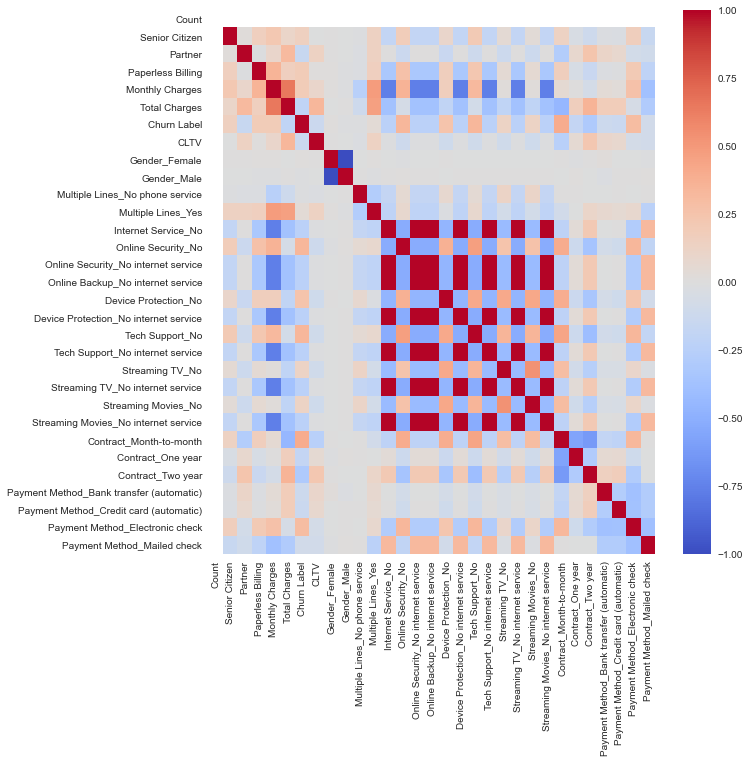

```python
# Display heatmap to view correlation between predictor variables
fig, ax = plt.subplots(figsize=(10,10))
sns.heatmap(Xfin.corr(), cmap='coolwarm')
plt.show()
```

- Several variables seem to be highly correlated. I will look for evidence of multicollinearity using Variable Inflation Factor analysis.

```python
# Look for evidence of Variance Inflation Factors (ref 5)

# VIF dataframe
vif_data = pd.DataFrame()
vif_data["feature"] = Xfin.columns

# calculating VIF for each feature
vif_data["VIF"] = [variance_inflation_factor(Xfin.values, i)
                          for i in range(len(Xfin.columns))]

print(vif_data)
```

```
                                     feature        VIF
0                                      Count   0.000000
1                             Senior Citizen   1.114063
2                                    Partner   1.162271
3                          Paperless Billing   1.210871
4                            Monthly Charges  12.991177
5                              Total Charges   4.196093
6                                Churn Label   1.389010
7                                       CLTV   1.176609
8                              Gender_Female        inf
9                                Gender_Male        inf
10           Multiple Lines_No phone service   2.339706
11                        Multiple Lines_Yes   1.580949
12                       Internet Service_No        inf
13                        Online Security_No   1.743672
```

[output cut: 17 more lines]

- Several variables have a VIF of an infinite value, so those variables will be dropped.

```python
# Drop columns with infinite VIF
drops = ['Gender_Female', 'Gender_Male', 'Internet Service_No', 'Online Security_No internet service',
         'Online Backup_No internet service', 'Device Protection_No internet service', 'Tech Support_No internet service',
         'Streaming TV_No internet service', 'Streaming Movies_No internet service', 'Contract_Month-to-month',
         'Contract_One year', 'Contract_One year', 'Contract_Two year', 'Payment Method_Bank transfer (automatic)',
         'Payment Method_Credit card (automatic)', 'Payment Method_Electronic check', 'Payment Method_Mailed check']
Xfin = Xfin.drop(drops, axis = 1)
```

```python
# Re-run model
Xcfin = sm.add_constant(Xfin)
linear_regression = sm.OLS(y,Xcfin)
fitted_model2 = linear_regression.fit()
fitted_model2.summary()
```

OLS Regression Results

| Dep. Variable: | y | R-squared: | 0.839 |
| --- | --- | --- | --- |
| Model: | OLS | Adj. R-squared: | 0.839 |
| Method: | Least Squares | F-statistic: | 2616. |
| Date: | Tue, 04 May 2021 | Prob (F-statistic): | 0.00 |
| Time: | 18:36:56 | Log-Likelihood: | -26097. |
| No. Observations: | 7043 | AIC: | 5.222e+04 |
| Df Residuals: | 7028 | BIC: | 5.233e+04 |
| Df Model: | 14 |  |  |
| Covariance Type: | nonrobust |  |  |

|  | coef | std err | t | P>\|t\| | [0.025 | 0.975] |
| --- | --- | --- | --- | --- | --- | --- |
| Count | 23.4624 | 0.581 | 40.362 | 0.000 | 22.323 | 24.602 |
| Senior Citizen | 0.5928 | 0.333 | 1.780 | 0.075 | -0.060 | 1.246 |
| Partner | 3.3252 | 0.251 | 13.223 | 0.000 | 2.832 | 3.818 |
| Paperless Billing | 0.1552 | 0.261 | 0.594 | 0.553 | -0.357 | 0.667 |
| Monthly Charges | -0.3791 | 0.007 | -50.756 | 0.000 | -0.394 | -0.364 |
| Total Charges | 0.0114 | 9.61e-05 | 118.411 | 0.000 | 0.011 | 0.012 |
| Churn Label | -1.9962 | 0.309 | -6.466 | 0.000 | -2.601 | -1.391 |
| CLTV | 0.0012 | 0.000 | 11.563 | 0.000 | 0.001 | 0.001 |
| Multiple Lines_No phone service | 1.2200 | 0.438 | 2.785 | 0.005 | 0.361 | 2.079 |
| Multiple Lines_Yes | 2.6502 | 0.288 | 9.212 | 0.000 | 2.086 | 3.214 |
| Online Security_No | -0.2669 | 0.299 | -0.892 | 0.373 | -0.854 | 0.320 |
| Device Protection_No | -0.2928 | 0.295 | -0.993 | 0.321 | -0.871 | 0.285 |
| Tech Support_No | 0.0013 | 0.303 | 0.004 | 0.997 | -0.592 | 0.595 |
| Streaming TV_No | -0.2654 | 0.298 | -0.889 | 0.374 | -0.851 | 0.320 |
| Streaming Movies_No | -0.1838 | 0.300 | -0.612 | 0.540 | -0.772 | 0.404 |

| Omnibus: | 183.842 | Durbin-Watson: | 2.017 |
| --- | --- | --- | --- |
| Prob(Omnibus): | 0.000 | Jarque-Bera (JB): | 266.618 |
| Skew: | 0.281 | Prob(JB): | 1.27e-58 |
| Kurtosis: | 3.771 | Cond. No. | 2.68e+04 |

Warnings:  
[1] Standard Errors assume that the covariance matrix of the errors is correctly specified.  
[2] The condition number is large, 2.68e+04. This might indicate that there are  
strong multicollinearity or other numerical problems.

- Several variables now have high p-values and will be dropped. I will then re-run the model and VIF analysis.

```python
drops = ['Senior Citizen', 'Paperless Billing', 'Online Security_No', 'Device Protection_No', 'Tech Support_No',
         'Streaming TV_No', 'Streaming Movies_No']
Xfin = Xfin.drop(drops, axis = 1)
```

```python
# Re-run model
Xcfin = sm.add_constant(Xfin)
linear_regression = sm.OLS(y,Xcfin)
fitted_model2 = linear_regression.fit()
fitted_model2.summary()
```

OLS Regression Results

| Dep. Variable: | y | R-squared: | 0.839 |
| --- | --- | --- | --- |
| Model: | OLS | Adj. R-squared: | 0.839 |
| Method: | Least Squares | F-statistic: | 5229. |
| Date: | Tue, 04 May 2021 | Prob (F-statistic): | 0.00 |
| Time: | 18:40:30 | Log-Likelihood: | -26102. |
| No. Observations: | 7043 | AIC: | 5.222e+04 |
| Df Residuals: | 7035 | BIC: | 5.227e+04 |
| Df Model: | 7 |  |  |
| Covariance Type: | nonrobust |  |  |

|  | coef | std err | t | P>\|t\| | [0.025 | 0.975] |
| --- | --- | --- | --- | --- | --- | --- |
| Count | 23.3509 | 0.574 | 40.714 | 0.000 | 22.227 | 24.475 |
| Partner | 3.3611 | 0.251 | 13.384 | 0.000 | 2.869 | 3.853 |
| Monthly Charges | -0.3843 | 0.006 | -62.950 | 0.000 | -0.396 | -0.372 |
| Total Charges | 0.0115 | 8.62e-05 | 133.077 | 0.000 | 0.011 | 0.012 |
| Churn Label | -1.9788 | 0.303 | -6.538 | 0.000 | -2.572 | -1.385 |
| CLTV | 0.0012 | 0.000 | 11.528 | 0.000 | 0.001 | 0.001 |
| Multiple Lines_No phone service | 1.0207 | 0.421 | 2.422 | 0.015 | 0.195 | 1.847 |
| Multiple Lines_Yes | 2.6857 | 0.287 | 9.360 | 0.000 | 2.123 | 3.248 |

| Omnibus: | 204.815 | Durbin-Watson: | 2.017 |
| --- | --- | --- | --- |
| Prob(Omnibus): | 0.000 | Jarque-Bera (JB): | 290.827 |
| Skew: | 0.312 | Prob(JB): | 7.04e-64 |
| Kurtosis: | 3.776 | Cond. No. | 2.64e+04 |

Warnings:  
[1] Standard Errors assume that the covariance matrix of the errors is correctly specified.  
[2] The condition number is large, 2.64e+04. This might indicate that there are  
strong multicollinearity or other numerical problems.

```python
# VIF dataframe
vif_data = pd.DataFrame()
vif_data["feature"] = Xfin.columns

# calculating VIF for each feature
vif_data["VIF"] = [variance_inflation_factor(Xfin.values, i)
                          for i in range(len(Xfin.columns))]

print(vif_data)
```

```
                           feature        VIF
0                            Count  23.867979
1                          Partner   1.142685
2                  Monthly Charges   2.448792
3                    Total Charges   2.765469
4                      Churn Label   1.295813
5                             CLTV   1.167854
6  Multiple Lines_No phone service   1.126745
7               Multiple Lines_Yes   1.457012
```

- I will drop the variable with a high VIF, then re-run the model.

```python
drops = ['Count']
Xfin = Xfin.drop(drops, axis = 1)
```

```python
# Re-run model
Xcfin = sm.add_constant(Xfin)
linear_regression = sm.OLS(y,Xcfin)
fitted_model2 = linear_regression.fit()
fitted_model2.summary()
```

OLS Regression Results

| Dep. Variable: | y | R-squared: | 0.839 |
| --- | --- | --- | --- |
| Model: | OLS | Adj. R-squared: | 0.839 |
| Method: | Least Squares | F-statistic: | 5229. |
| Date: | Tue, 04 May 2021 | Prob (F-statistic): | 0.00 |
| Time: | 18:42:33 | Log-Likelihood: | -26102. |
| No. Observations: | 7043 | AIC: | 5.222e+04 |
| Df Residuals: | 7035 | BIC: | 5.227e+04 |
| Df Model: | 7 |  |  |
| Covariance Type: | nonrobust |  |  |

|  | coef | std err | t | P>\|t\| | [0.025 | 0.975] |
| --- | --- | --- | --- | --- | --- | --- |
| const | 23.3509 | 0.574 | 40.714 | 0.000 | 22.227 | 24.475 |
| Partner | 3.3611 | 0.251 | 13.384 | 0.000 | 2.869 | 3.853 |
| Monthly Charges | -0.3843 | 0.006 | -62.950 | 0.000 | -0.396 | -0.372 |
| Total Charges | 0.0115 | 8.62e-05 | 133.077 | 0.000 | 0.011 | 0.012 |
| Churn Label | -1.9788 | 0.303 | -6.538 | 0.000 | -2.572 | -1.385 |
| CLTV | 0.0012 | 0.000 | 11.528 | 0.000 | 0.001 | 0.001 |
| Multiple Lines_No phone service | 1.0207 | 0.421 | 2.422 | 0.015 | 0.195 | 1.847 |
| Multiple Lines_Yes | 2.6857 | 0.287 | 9.360 | 0.000 | 2.123 | 3.248 |

| Omnibus: | 204.815 | Durbin-Watson: | 2.017 |
| --- | --- | --- | --- |
| Prob(Omnibus): | 0.000 | Jarque-Bera (JB): | 290.827 |
| Skew: | 0.312 | Prob(JB): | 7.04e-64 |
| Kurtosis: | 3.776 | Cond. No. | 2.64e+04 |

Warnings:  
[1] Standard Errors assume that the covariance matrix of the errors is correctly specified.  
[2] The condition number is large, 2.64e+04. This might indicate that there are  
strong multicollinearity or other numerical problems.

##### Model Comparison

The initial model of all numeric variables in the provided data set contained 67 independent variables. The inclusion of so many variables inflated the R squared value, which can describe how accurate the model is, resulting in the perfect score of 1.0. Variables were removed first by considering their significance, by utilizing the calculation of their p-value from the model, and by recalculating the model after each deletion to again assess the p-value. Once the insignificant variables were eliminated, the focus was then turned to instances of multicollinearity, as variables that behave similarly can be problematic for predictions as they mean that certain variables are not truly independent of each other. To identify those variables, I used a tool that tested variance inflation factors (VIF) which can measure how much each variable is being affected by other variables (Bhandari, 2020). As with p-values, lower scores are desirable for VIF and should ideally be under 5. In the tutorials that I read, variables with similar scores were related and models improved when removing one of each related pair of variables. I did not see cases in my dataset where VIF scores were similar to be able to decide between two variables. Several variables came back with a score of "inf" (infinite), therefore I chose to remove all of those variables for my final model since I couldn't determine which of those variables might be pairs that I could keep one of. In my final model, there were seven independent variables, meaning 60 were removed.

My final model had an R squared value of 0.839. This means that the regression model explains approximately 83.9% of the variation in the sample values of the number of months of a customer's tenure. This value was slightly lower in the final model than the initial model, however, the final equation would be a better determination of how well the model would perform when answering the research question.

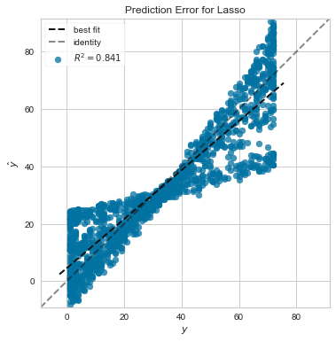

```python
# Display prediction error plot to determine the amount of variance in model (ref 6)
mpl.rcParams['figure.figsize'] = (9,6)

# Create the train and test data
X_train, X_test, y_train, y_test = train_test_split(Xfin, y, test_size=0.2, random_state=42)

model = Lasso()
visualizer = PredictionError(model)

visualizer.fit(X_train, y_train)  # Fit the training data to the visualizer
visualizer.score(X_test, y_test)  # Evaluate the model on the test data
g = visualizer.poof()             # Draw/show/poof the data
```

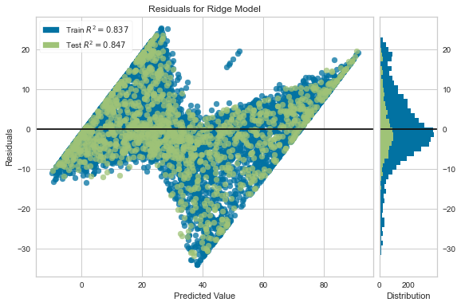

```python
# Display residuals plot (ref 6)
model = Ridge()
visualizer = ResidualsPlot(model)

visualizer.fit(X_train, y_train)  # Fit the training data to the visualizer
visualizer.score(X_test, y_test)  # Evaluate the model on the test data
g = visualizer.poof()             # Draw/show/poof the data
```

```python
# Create dataframe of coefficients for regression equation (ref 7)
regressor = LinearRegression()
regressor.fit(Xfin, y)
coeff_df = pd.DataFrame(regressor.coef_.round(decimals = 2), Xfin.columns, columns = ['Coefficient'])
coeff_df['Variable'] = coeff_df.index

# Print regression equation
equation = 'y = '
y1 = regressor.intercept_.round(decimals = 2)
equation += str(y1)
for index, row in coeff_df.iterrows():
    if row['Coefficient'] < 0:
        c = str(row.Coefficient)
        equation += c + '(' + row['Variable'] + ')'
    else:
        c = str(row.Coefficient)
        equation += '+' + c + '(' + row['Variable'] + ')'
print(equation)
```

```
y = 23.35+3.36(Partner)-0.38(Monthly Charges)+0.01(Total Charges)-1.98(Churn Label)+0.0(CLTV)+1.02(Multiple Lines_No phone service)+2.69(Multiple Lines_Yes)
```

#### Results

The equation of the final regression model is: y = 23.35 + 3.36(Partner) - 0.38(Monthly Charges) + 0.01(Total Charges) - 1.98(Churn Label) + 0.0(CLTV) + 1.02(Multiple Lines_No phone service) + 2.69(Multiple Lines_Yes). In this equation, 23.35 is the value of Tenure when all of the predictor variables are zero. Each coefficient of the predictor variables describes how much the target variable is estimated to change if all other variables remain constant. For example, if Multiple Lines_Yes increased by one unit, the mean value of Tenure would increase by 2.69. Beyond that Partner seems to have the largest effect on tenure positively by 3.36.

#### Sources

Bhandari, A. (2020). Multicollinearity | Detecting Multicollinearity with VIF. Analytics Vidhya. Retrieved 8 January 2021, from https://www.analyticsvidhya.com/blog/2020/03/what-is-multicollinearity/. Massaron, L., & Boschetti, A. (2016). Regression analysis with Python. Packt Publishing. ISBN: 9781785286315 McIntyre, K. (2018, August 18). Yellowbrick - Regression Visualizer Examples. Retrieved January 08, 2021, from https://www.kaggle.com/kautumn06/yellowbrick-regression-visualizer-examples

#### Helpful Sites Used in Coding Project

1. https://stackoverflow.com/questions/51672709/converting-no-and-yes-into-0-and-1-in-pandas-dataframe/51672855
2. https://stackoverflow.com/questions/61526812/boxplot-for-all-data-in-dataframe-error-numpy-ndarray-object-has-no-attribut
3. https://datascience.stackexchange.com/questions/84840/how-to-create-multiple-subplots-scatterplot-in-for-loop
4. https://stackoverflow.com/questions/31290778/add-custom-border-to-certain-cells-in-a-matplotlib-seaborn-plot
5. https://analyticsvidhya.com/blog/2020/03/what-is-multicollinearity/
6. https://www.kaggle.com/kautumn06/yellowbrick-regression-visualizer-examples
7. https://www.kdnuggets.com/2019/03/beginners-guide-linear-regression-python-scikit-learn.html/2
8. https://stackoverflow.com/questions/59740434/how-to-print-intercept-and-slope-of-a-simple-linear-regression-in-python-with-sc